[output not shown]

[output not shown]

[output not shown]

# Simple descriptive plots of explanatory variables

Consider age, sex, severity and Days.FFS as explanatory variables.

| Sex | Count | % |
| --- | --- | --- |
| M | 59 | 56.19048 |
| F | 46 | 43.80952 |

The age distribution, proxied by 2020 - year of birth, was broadly similar between males and females, with median “age” 53 overall, although males were on average slightly older.

| Sex | Median | LQR | UQR |
| --- | --- | --- | --- |
| All | 53.0 | 49 | 61.00 |
| M | 55.0 | 49 | 63.00 |
| F | 51.5 | 48 | 56.75 |

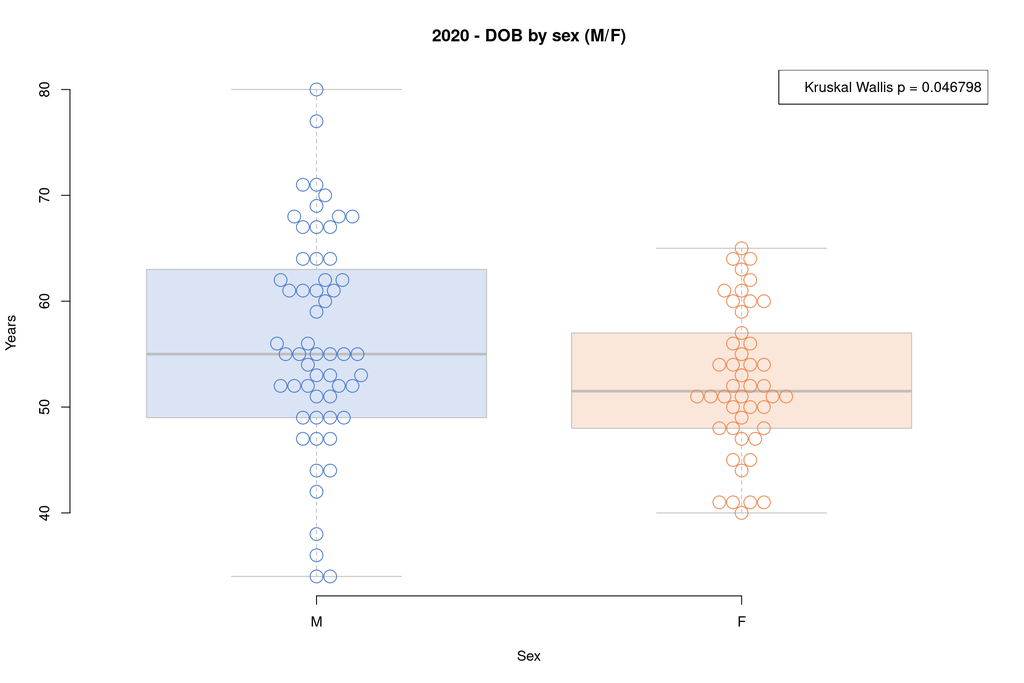

```
## Of 94 patients who reported symptom onset and a PCR date, reported symtom onset was a median of 5 days before their PCR tests, but this ranged from  -3 - 19 days.
```

```
##    Min. 1st Qu.  Median    Mean 3rd Qu.    Max.    NA's
##   -3.00    2.00    5.00    5.67    9.00   19.00      11
```

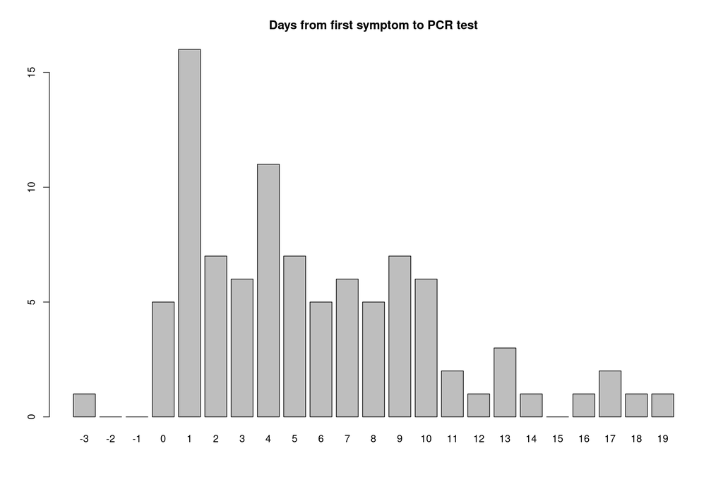

There are 3 classes of severity, with 2 unknowns. Severe disease is over represented in males and older individuals

| Severity | Count | % |
| --- | --- | --- |
| 1 | 53 | 50.476191 |
| 2 | 31 | 29.523809 |
| 3 | 19 | 18.095238 |
| NA | 2 | 1.904762 |

| Sex | Severity | Count | % |
| --- | --- | --- | --- |
| M | 1 | 25 | 23.809524 |
| F | 1 | 28 | 26.666667 |
| F | 2 | 14 | 13.333333 |
| M | 2 | 17 | 16.190476 |
| M | 3 | 16 | 15.238095 |
| F | 3 | 3 | 2.857143 |

```
## [1] "Counts"
```

```
##    Severity
## Sex  1  2  3
##   M 25 17 16
##   F 28 14  3
```

```
## [1] "%"
```

```
##    Severity
## Sex         1         2         3
##   M 24.271845 16.504854 15.533981
##   F 27.184466 13.592233  2.912621
```

```
##
##  Fisher's Exact Test for Count Data
##
## data:  tt
## p-value = 0.01933
## alternative hypothesis: two.sided
```

| Severity | Median | LQR | UQR |
| --- | --- | --- | --- |
| All | 53 | 49.0 | 61.0 |
| 1 | 52 | 48.0 | 56.0 |
| 2 | 53 | 49.5 | 61.0 |
| 3 | 62 | 55.0 | 68.5 |

```
##
##  Kruskal-Wallis rank sum test
##
## data:  Years by Severity
## Kruskal-Wallis chi-squared = 11.142, df = 2, p-value = 0.003807
```

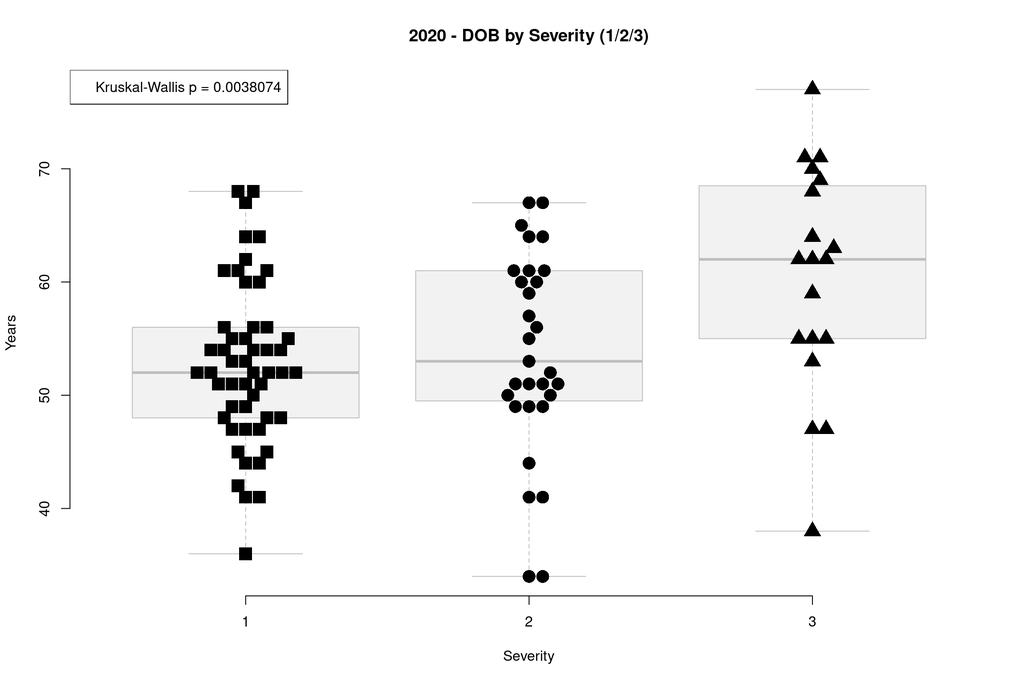

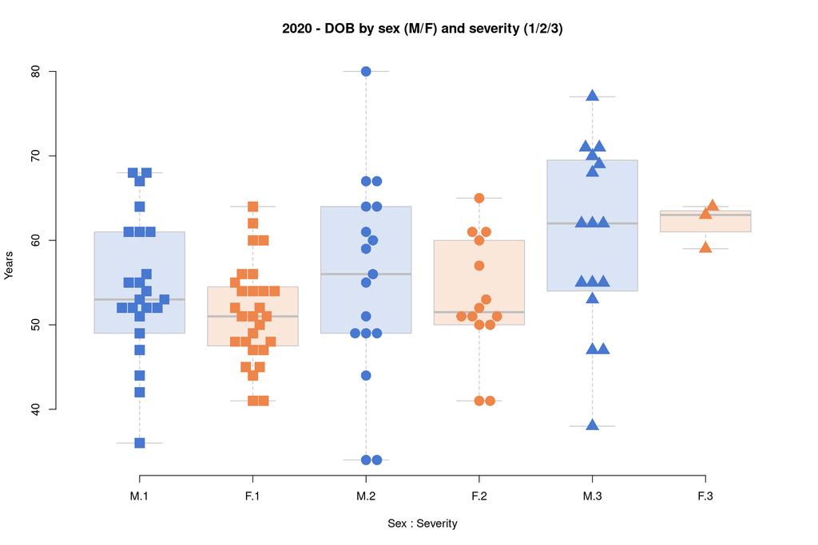

Sex, Severity and DOB are independent of Days.FSS

```
##
##  Spearman's rank correlation rho
##
## data:  Days.FFS and Years
## S = 150885, p-value = 0.9383
## alternative hypothesis: true rho is not equal to 0
## sample estimates:
##         rho
## 0.007960111
```

```
##
##  Kruskal-Wallis rank sum test
##
## data:  Days.FFS by Sex
## Kruskal-Wallis chi-squared = 0.021361, df = 1, p-value = 0.8838
```

```
##
##  Kruskal-Wallis rank sum test
##
## data:  Days.FFS by Severity
## Kruskal-Wallis chi-squared = 0.94358, df = 2, p-value = 0.6239
```

## Univariate analysis of Ig measures

```
##    COVID.Patient.ID Days.FFS Severity Sex  DOB Days.PCR Years variable value
## 1:                1       18        3   M 1952        9    68    S.IgM 1.524
## 2:                2       22        2   F 1970       17    50    S.IgM 1.415
## 3:                3       13        1   M 1971       16    49    S.IgM 1.137
## 4:                4       17        1   F 1968       16    52    S.IgM 0.339
## 5:                5       21        2   M 1964       19    56    S.IgM 1.296
## 6:                6       19        1   F 1976       17    44    S.IgM 0.240
```

```
##     variable Sex Number median     LQR     UQR
##  1:    S.IgM   M     59 0.8390 0.45250 1.16950
##  2:    S.IgM   F     46 0.8265 0.36025 1.06275
##  3:  RBD.IgM   M     59 0.7840 0.44800 1.18000
##  4:  RBD.IgM   F     46 0.6230 0.28375 1.04600
##  5:    S.IgG   M     59 1.0470 0.96600 1.20000
##  6:    S.IgG   F     46 1.0385 0.87975 1.19500
##  7:  RBD.IgG   M     59 0.9650 0.71100 1.04950
##  8:  RBD.IgG   F     46 0.8440 0.57225 0.99250
##  9:    S.IgA   M     59 0.7250 0.44100 1.19950
## 10:    S.IgA   F     46 0.5070 0.25825 0.77725
## 11:  RBD.IgA   M     59 0.6410 0.29050 1.06200
## 12:  RBD.IgA   F     46 0.2680 0.16950 0.51500
```

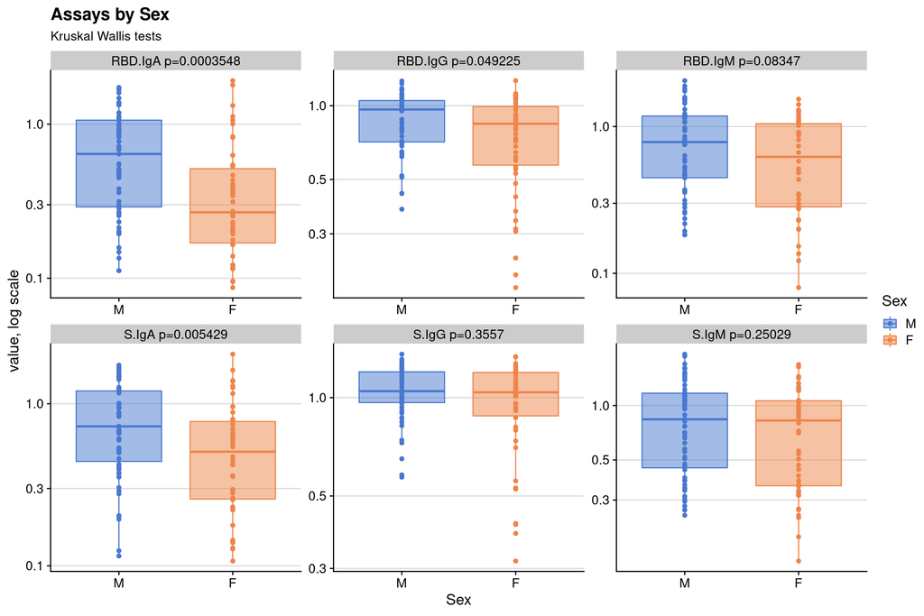

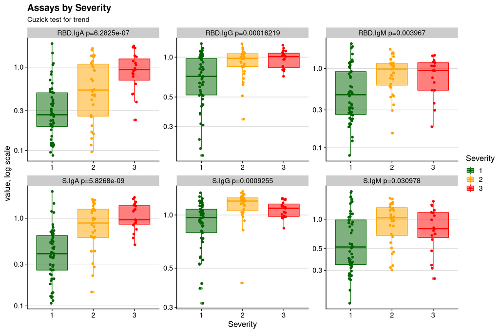

IgG levels tended to trend up with days from first symptom while IgA and IgM showed downwards trends. Similar patterns were seen with days from PCR+, although trends were stronger for IgA and IgM, but no convincing trend for IgG.

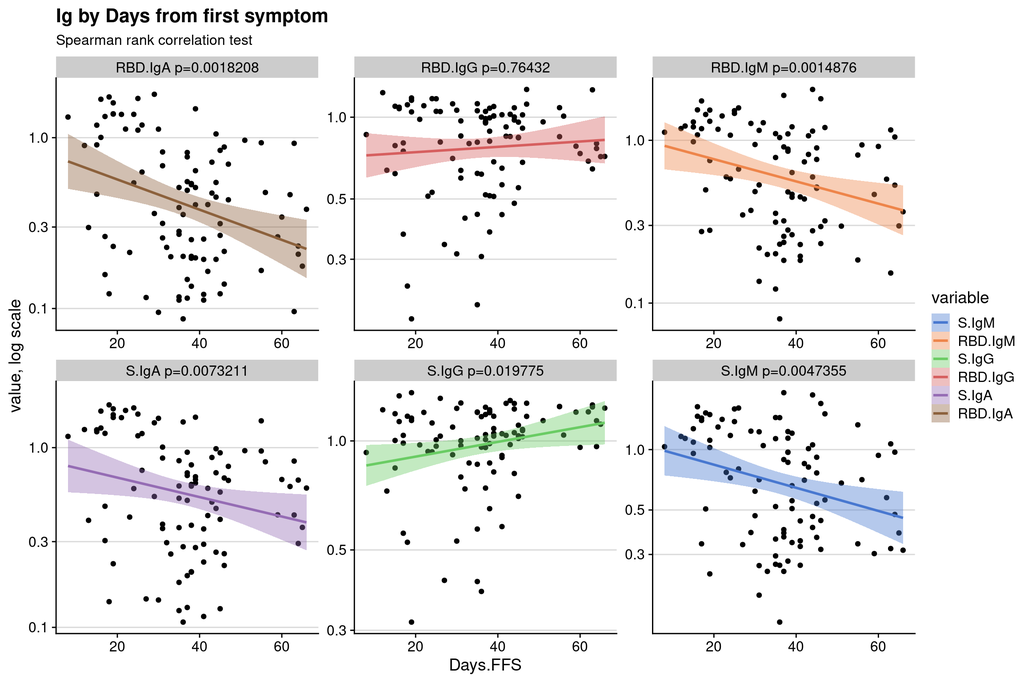

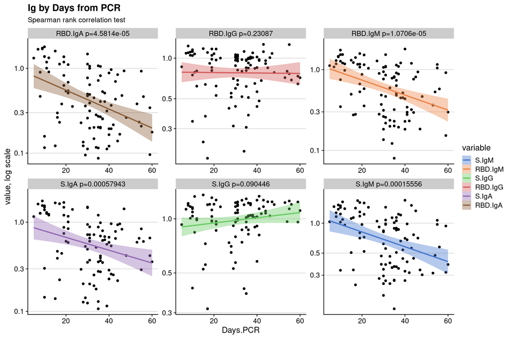

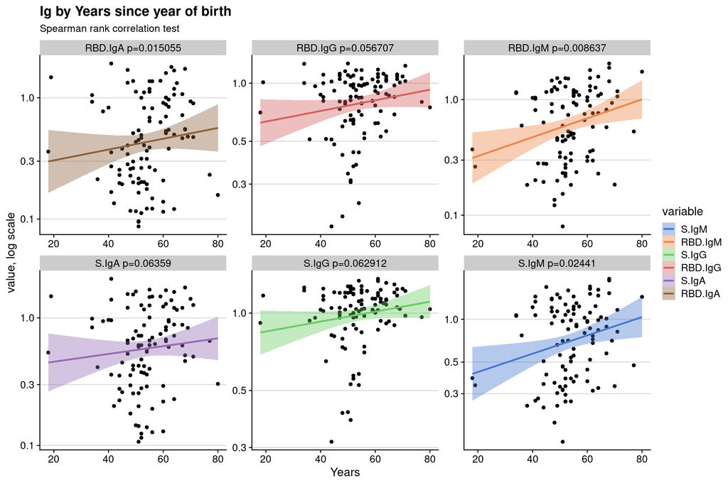

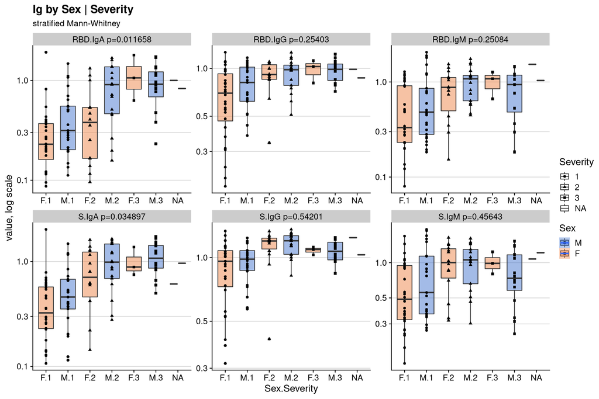

# Relationship of IL-6 and PSV to antibody levels

IL-6 showed positive correlations with IgA levels and PSV.ID50 both showed positive correlations with all Ig levels.

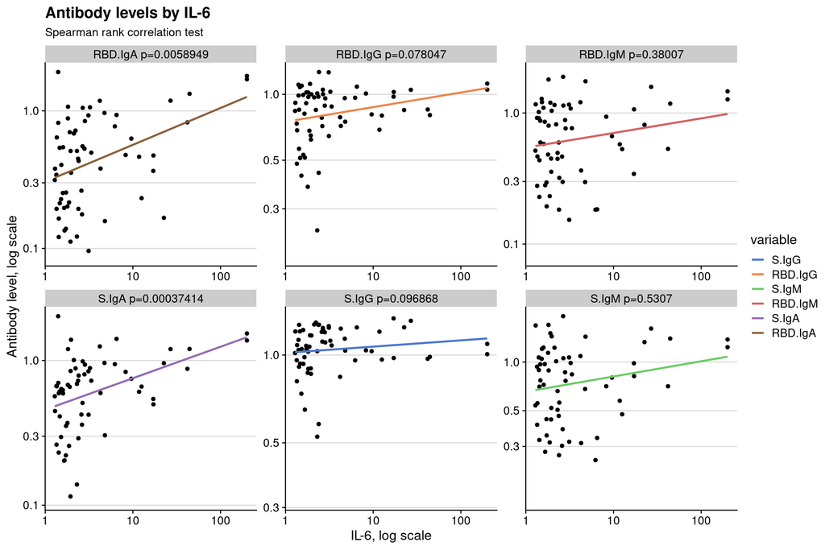

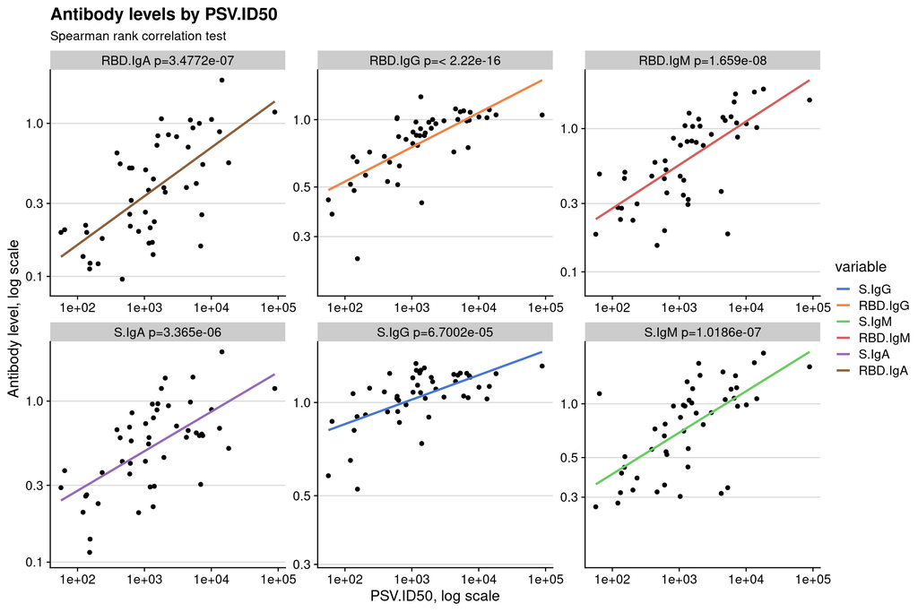

IL-6 and PSV.ID50 themselves showed a non-significant positive relationship (p=0.2).

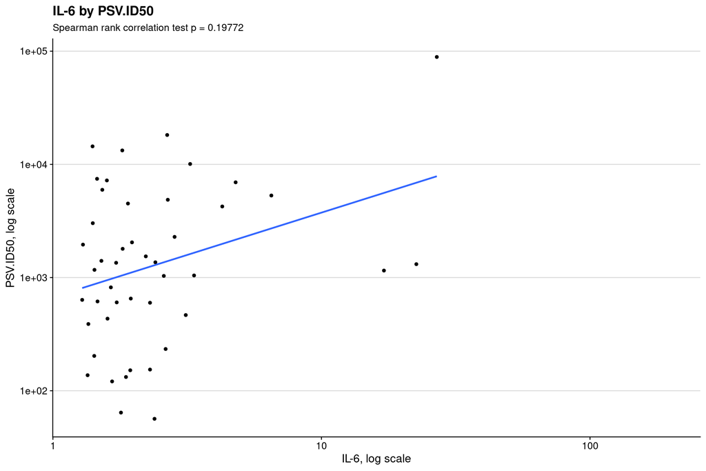

## Multivariate analysis of biochemical measures

We fit multivariate linear models to log transformed assay data, to try and separate out effects of severity, sex, years and Days. Overall, severity showed the most consistent relationship with any measure, and suggests that the weaker univariate relationships with Sex and Years above are probably indirect associations reflecting the relationships between Sex, Years and Severity, with Severity the primary driver of differences in Ig levels.

### IL.6

|  | Estimate | Std. Error | t value | Pr(>\|t\|) |
| --- | --- | --- | --- | --- |
| (Intercept) | 1.0808524 | 0.7558497 | 1.4299833 | 0.1589412 |
| Days.FFS | -0.0138028 | 0.0092132 | -1.4981536 | 0.1403806 |
| Severity2 | 0.6751029 | 0.2725780 | 2.4767330 | 0.0166860 |
| Severity3 | 2.0818073 | 0.3139723 | 6.6305441 | 0.0000000 |
| SexF | -0.0048214 | 0.2490798 | -0.0193569 | 0.9846335 |
| Years | 0.0006194 | 0.0120141 | 0.0515519 | 0.9590912 |

*checking robustness with 2 outliers removed*

|  | Estimate | Std. Error | t value | Pr(>\|t\|) |
| --- | --- | --- | --- | --- |
| (Intercept) | 0.5938320 | 0.6085196 | 0.9758633 | 0.3340249 |
| Days.FFS | -0.0048689 | 0.0073761 | -0.6600921 | 0.5123499 |
| Severity2 | 0.6314650 | 0.2134847 | 2.9578929 | 0.0047955 |
| Severity3 | 1.5427576 | 0.2627737 | 5.8710497 | 0.0000004 |
| SexF | -0.1881632 | 0.2020666 | -0.9311939 | 0.3564134 |
| Years | 0.0047880 | 0.0095726 | 0.5001784 | 0.6192350 |

### PSV.ID50

|  | Estimate | Std. Error | t value | Pr(>\|t\|) |
| --- | --- | --- | --- | --- |
| (Intercept) | 4.5012562 | 1.8338893 | 2.4544864 | 0.0193831 |
| Days.FFS | -0.0150209 | 0.0222419 | -0.6753408 | 0.5040267 |
| Severity2 | 1.4888195 | 0.5062151 | 2.9410804 | 0.0058489 |
| Severity3 | 1.4175205 | 1.0591033 | 1.3384157 | 0.1896430 |
| SexF | -0.1325308 | 0.4944022 | -0.2680627 | 0.7902707 |
| Years | 0.0484696 | 0.0266019 | 1.8220360 | 0.0772562 |

*checking robustness with 1 outlier removed*

|  | Estimate | Std. Error | t value | Pr(>\|t\|) |
| --- | --- | --- | --- | --- |
| (Intercept) | 4.5186312 | 1.7467553 | 2.5868713 | 0.0142822 |
| Days.FFS | -0.0063506 | 0.0215775 | -0.2943131 | 0.7703621 |
| Severity2 | 1.2195131 | 0.4986724 | 2.4455196 | 0.0199661 |
| Severity3 | 1.4434429 | 1.0088452 | 1.4307873 | 0.1618932 |
| SexF | -0.0004480 | 0.4750254 | -0.0009431 | 0.9992532 |
| Years | 0.0403811 | 0.0256244 | 1.5758858 | 0.1245916 |

### S.IgG

|  | Estimate | Std. Error | t value | Pr(>\|t\|) |
| --- | --- | --- | --- | --- |
| (Intercept) | -0.4338183 | 0.1572226 | -2.7592622 | 0.0070039 |
| Days.FFS | 0.0056162 | 0.0018643 | 3.0124437 | 0.0033555 |
| Severity2 | 0.2636915 | 0.0582979 | 4.5231746 | 0.0000183 |
| Severity3 | 0.1553421 | 0.0760363 | 2.0429981 | 0.0439450 |
| SexF | -0.1061612 | 0.0537241 | -1.9760431 | 0.0511786 |
| Years | 0.0025710 | 0.0026281 | 0.9782727 | 0.3305330 |

### RBD.IgG

|  | Estimate | Std. Error | t value | Pr(>\|t\|) |
| --- | --- | --- | --- | --- |
| (Intercept) | -0.5916830 | 0.2306770 | -2.5649851 | 0.0119546 |
| Days.FFS | 0.0034375 | 0.0027353 | 1.2566928 | 0.2120811 |
| Severity2 | 0.3166891 | 0.0855347 | 3.7024646 | 0.0003657 |
| Severity3 | 0.3183027 | 0.1115605 | 2.8531842 | 0.0053580 |
| SexF | -0.1630434 | 0.0788241 | -2.0684471 | 0.0414354 |
| Years | 0.0021569 | 0.0038560 | 0.5593721 | 0.5772819 |

### S.IgM

|  | Estimate | Std. Error | t value | Pr(>\|t\|) |
| --- | --- | --- | --- | --- |
| (Intercept) | -0.8300628 | 0.3562796 | -2.3298074 | 0.0220285 |
| Days.FFS | -0.0117670 | 0.0042247 | -2.7852943 | 0.0065067 |
| Severity2 | 0.4216830 | 0.1321079 | 3.1919588 | 0.0019404 |
| Severity3 | 0.1256475 | 0.1723047 | 0.7292168 | 0.4677418 |
| SexF | -0.1603918 | 0.1217434 | -1.3174576 | 0.1909928 |
| Years | 0.0144308 | 0.0059556 | 2.4230696 | 0.0173698 |

### RBD.IgM

|  | Estimate | Std. Error | t value | Pr(>\|t\|) |
| --- | --- | --- | --- | --- |
| (Intercept) | -1.0387929 | 0.4130592 | -2.5148767 | 0.0136629 |
| Days.FFS | -0.0138623 | 0.0048980 | -2.8302083 | 0.0057240 |
| Severity2 | 0.5057259 | 0.1531617 | 3.3019087 | 0.0013732 |
| Severity3 | 0.1944795 | 0.1997646 | 0.9735434 | 0.3328641 |
| SexF | -0.2399048 | 0.1411454 | -1.6996999 | 0.0926033 |
| Years | 0.0171226 | 0.0069047 | 2.4798392 | 0.0149844 |

### S.IgA

|  | Estimate | Std. Error | t value | Pr(>\|t\|) |
| --- | --- | --- | --- | --- |
| (Intercept) | -0.2343625 | 0.3626807 | -0.6461952 | 0.5197793 |
| Days.FFS | -0.0097902 | 0.0043006 | -2.2764744 | 0.0251627 |
| Severity2 | 0.7529383 | 0.1344814 | 5.5988283 | 0.0000002 |
| Severity3 | 1.0042292 | 0.1754004 | 5.7253524 | 0.0000001 |
| SexF | -0.2661040 | 0.1239307 | -2.1472001 | 0.0344358 |
| Years | -0.0057710 | 0.0060626 | -0.9519015 | 0.3436685 |

### RBD.IgA

|  | Estimate | Std. Error | t value | Pr(>\|t\|) |
| --- | --- | --- | --- | --- |
| (Intercept) | -0.2710503 | 0.4094717 | -0.6619513 | 0.5096753 |
| Days.FFS | -0.0180531 | 0.0048554 | -3.7181129 | 0.0003466 |
| Severity2 | 0.5614106 | 0.1518315 | 3.6975911 | 0.0003718 |
| Severity3 | 0.9648132 | 0.1980296 | 4.8720661 | 0.0000046 |
| SexF | -0.4683261 | 0.1399195 | -3.3471098 | 0.0011886 |
| Years | -0.0023814 | 0.0068447 | -0.3479188 | 0.7287046 |

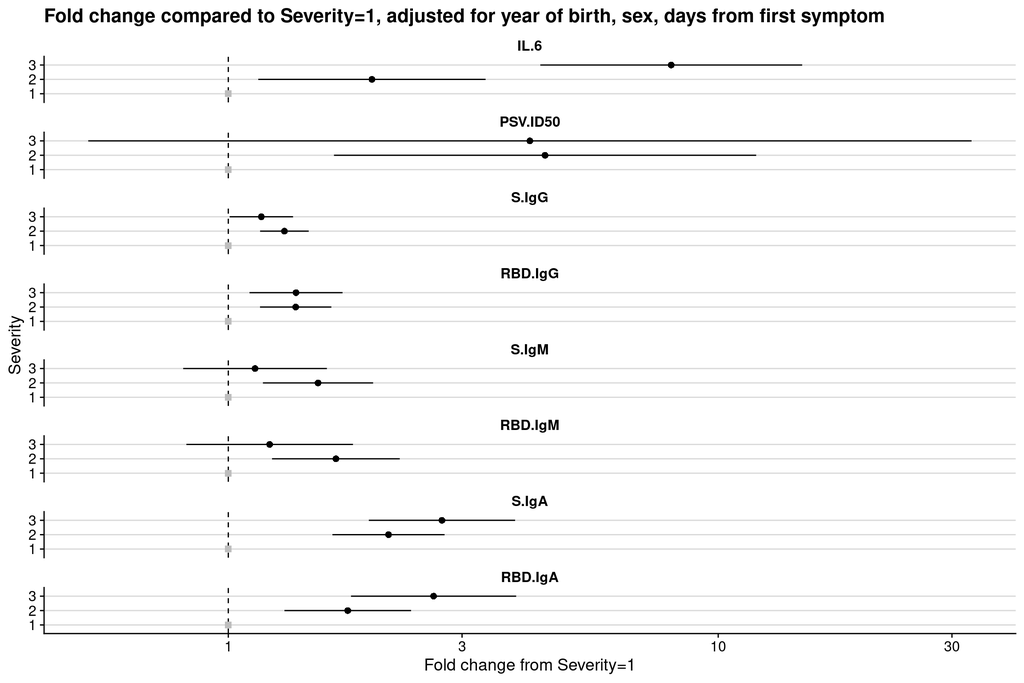

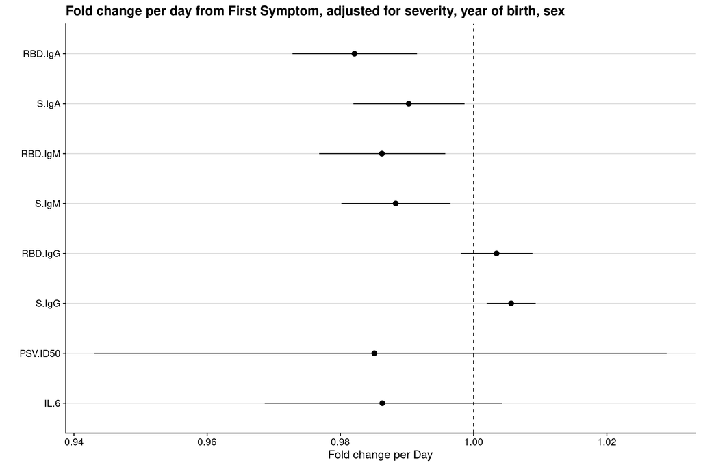

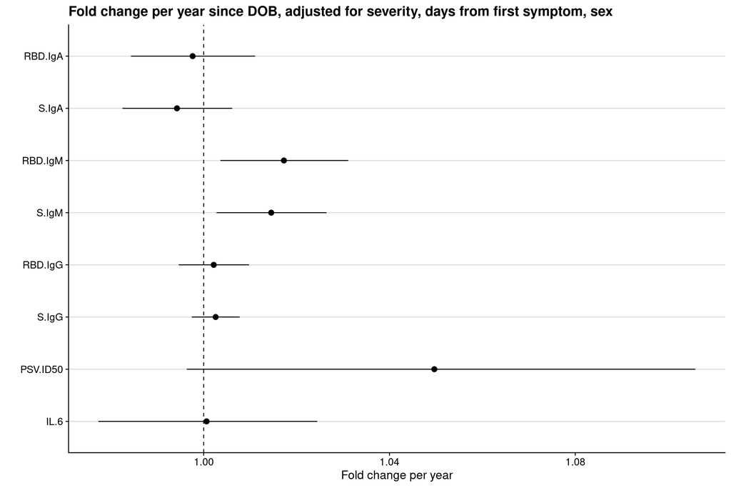

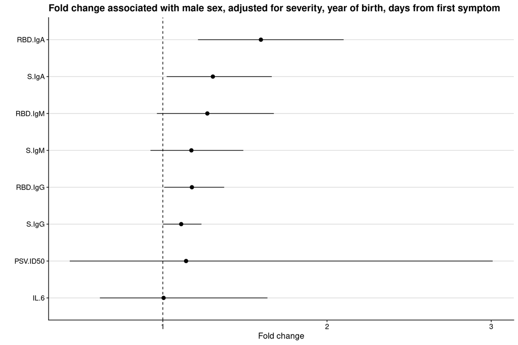

### IL.6

|  | Estimate | Std. Error | t value | Pr(>\|t\|) |
| --- | --- | --- | --- | --- |
| (Intercept) | 1.3337536 | 0.7900611 | 1.6881651 | 0.0972562 |
| Days.PCR | -0.0179820 | 0.0091674 | -1.9615105 | 0.0550817 |
| Severity2 | 0.5419503 | 0.2784989 | 1.9459695 | 0.0569693 |
| Severity3 | 1.7879936 | 0.3174311 | 5.6326988 | 0.0000007 |
| SexF | -0.0418102 | 0.2496296 | -0.1674892 | 0.8676226 |
| Years | -0.0002995 | 0.0127464 | -0.0234942 | 0.9813443 |

*checking robustness with 2 outliers removed*

|  | Estimate | Std. Error | t value | Pr(>\|t\|) |
| --- | --- | --- | --- | --- |
| (Intercept) | 0.7050756 | 0.6754753 | 1.0438215 | 0.3014906 |
| Days.PCR | -0.0046541 | 0.0079825 | -0.5830368 | 0.5624379 |
| Severity2 | 0.5212971 | 0.2297047 | 2.2694227 | 0.0275018 |
| Severity3 | 1.3678120 | 0.2739547 | 4.9928394 | 0.0000073 |
| SexF | -0.1798193 | 0.2123891 | -0.8466500 | 0.4011457 |
| Years | 0.0039051 | 0.0107259 | 0.3640784 | 0.7173046 |

### PSV.ID50

|  | Estimate | Std. Error | t value | Pr(>\|t\|) |
| --- | --- | --- | --- | --- |
| (Intercept) | 5.2752610 | 1.6958032 | 3.1107742 | 0.0035845 |
| Days.PCR | -0.0282459 | 0.0190912 | -1.4795302 | 0.1474633 |
| Severity2 | 1.4647193 | 0.4544978 | 3.2227205 | 0.0026504 |
| Severity3 | 1.9419796 | 0.7912711 | 2.4542533 | 0.0189450 |
| SexF | 0.1871493 | 0.4244939 | 0.4408763 | 0.6618680 |
| Years | 0.0378735 | 0.0253337 | 1.4949856 | 0.1433991 |

*checking robustness with 1 outlier removed*

|  | Estimate | Std. Error | t value | Pr(>\|t\|) |
| --- | --- | --- | --- | --- |
| (Intercept) | 5.3454881 | 1.5958448 | 3.3496292 | 0.0019089 |
| Days.PCR | -0.0197376 | 0.0183073 | -1.0781255 | 0.2881490 |
| Severity2 | 1.2106216 | 0.4404721 | 2.7484639 | 0.0092996 |
| Severity3 | 1.9906995 | 0.7447805 | 2.6728673 | 0.0112300 |
| SexF | 0.3062324 | 0.4024577 | 0.7609059 | 0.4516688 |
| Years | 0.0297967 | 0.0240715 | 1.2378418 | 0.2237872 |

### S.IgG

|  | Estimate | Std. Error | t value | Pr(>\|t\|) |
| --- | --- | --- | --- | --- |
| (Intercept) | -0.3943762 | 0.1612688 | -2.4454589 | 0.0163490 |
| Days.PCR | 0.0055996 | 0.0019357 | 2.8928024 | 0.0047551 |
| Severity2 | 0.2736918 | 0.0600135 | 4.5605006 | 0.0000155 |
| Severity3 | 0.1924181 | 0.0764924 | 2.5155192 | 0.0136010 |
| SexF | -0.0761660 | 0.0536223 | -1.4204181 | 0.1588299 |
| Years | 0.0021211 | 0.0027262 | 0.7780124 | 0.4385365 |

### RBD.IgG

|  | Estimate | Std. Error | t value | Pr(>\|t\|) |
| --- | --- | --- | --- | --- |
| (Intercept) | -0.4864143 | 0.2323367 | -2.0935746 | 0.0390193 |
| Days.PCR | 0.0026259 | 0.0027887 | 0.9416332 | 0.3488201 |
| Severity2 | 0.3090881 | 0.0864603 | 3.5749131 | 0.0005579 |
| Severity3 | 0.3412088 | 0.1102011 | 3.0962391 | 0.0025904 |
| SexF | -0.1373444 | 0.0772525 | -1.7778632 | 0.0786949 |
| Years | 0.0009867 | 0.0039277 | 0.2512189 | 0.8021991 |

### S.IgM

|  | Estimate | Std. Error | t value | Pr(>\|t\|) |
| --- | --- | --- | --- | --- |
| (Intercept) | -0.7023442 | 0.3495024 | -2.0095550 | 0.0473764 |
| Days.PCR | -0.0140527 | 0.0041950 | -3.3498589 | 0.0011693 |
| Severity2 | 0.3945068 | 0.1300616 | 3.0332313 | 0.0031359 |
| Severity3 | 0.1480218 | 0.1657746 | 0.8929099 | 0.3742101 |
| SexF | -0.0547174 | 0.1162104 | -0.4708481 | 0.6388518 |
| Years | 0.0113959 | 0.0059083 | 1.9287769 | 0.0568080 |

### RBD.IgM

|  | Estimate | Std. Error | t value | Pr(>\|t\|) |
| --- | --- | --- | --- | --- |
| (Intercept) | -0.8655000 | 0.3973594 | -2.178129 | 0.0319255 |
| Days.PCR | -0.0172033 | 0.0047694 | -3.606981 | 0.0005008 |
| Severity2 | 0.4913299 | 0.1478708 | 3.322698 | 0.0012758 |
| Severity3 | 0.2406897 | 0.1884739 | 1.277045 | 0.2047656 |
| SexF | -0.1394645 | 0.1321230 | -1.055566 | 0.2939009 |
| Years | 0.0133309 | 0.0067174 | 1.984546 | 0.0501421 |

### S.IgA

|  | Estimate | Std. Error | t value | Pr(>\|t\|) |
| --- | --- | --- | --- | --- |
| (Intercept) | -0.3012762 | 0.3728826 | -0.8079654 | 0.4211724 |
| Days.PCR | -0.0098957 | 0.0044757 | -2.2110117 | 0.0294865 |
| Severity2 | 0.6714710 | 0.1387621 | 4.8390072 | 0.0000052 |
| Severity3 | 0.9000684 | 0.1768642 | 5.0890358 | 0.0000019 |
| SexF | -0.2758111 | 0.1239844 | -2.2245634 | 0.0285297 |
| Years | -0.0041292 | 0.0063036 | -0.6550579 | 0.5140475 |

### RBD.IgA

|  | Estimate | Std. Error | t value | Pr(>\|t\|) |
| --- | --- | --- | --- | --- |
| (Intercept) | -0.2267285 | 0.4122576 | -0.5499679 | 0.5836598 |
| Days.PCR | -0.0196414 | 0.0049483 | -3.9693438 | 0.0001418 |
| Severity2 | 0.4589973 | 0.1534149 | 2.9918687 | 0.0035499 |
| Severity3 | 0.8788819 | 0.1955404 | 4.4946297 | 0.0000200 |
| SexF | -0.4433399 | 0.1370767 | -3.2342474 | 0.0016890 |
| Years | -0.0029664 | 0.0069692 | -0.4256455 | 0.6713496 |

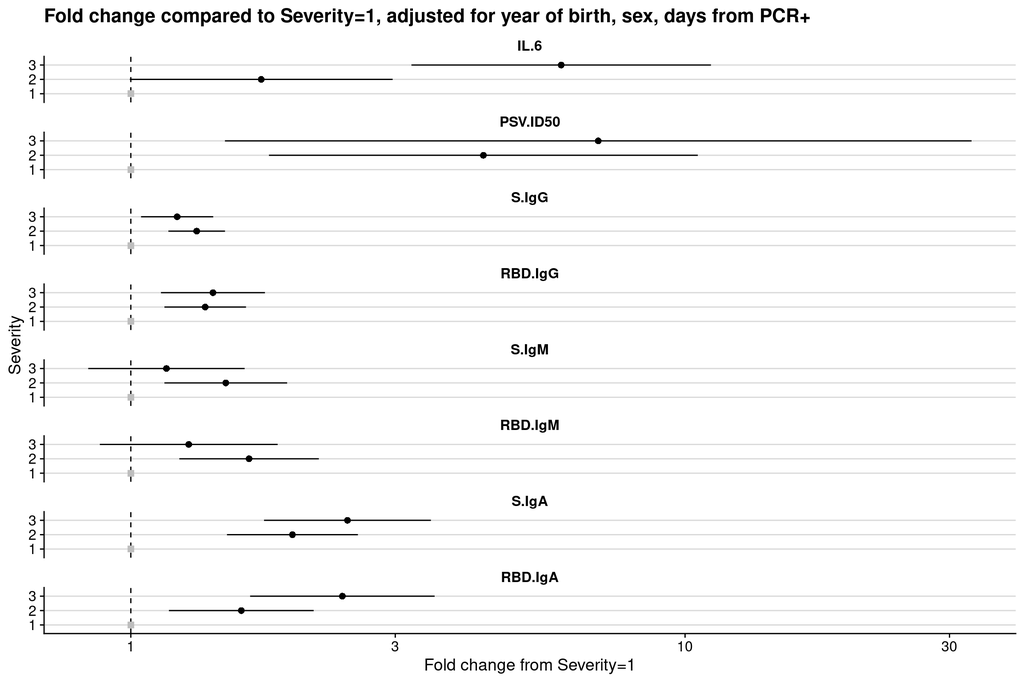

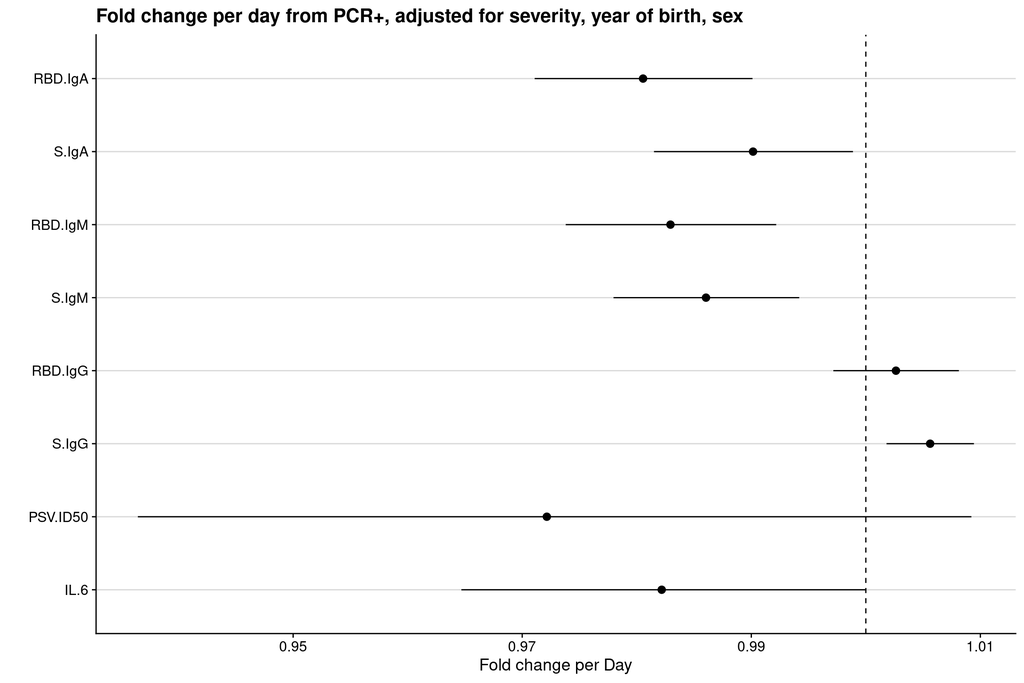

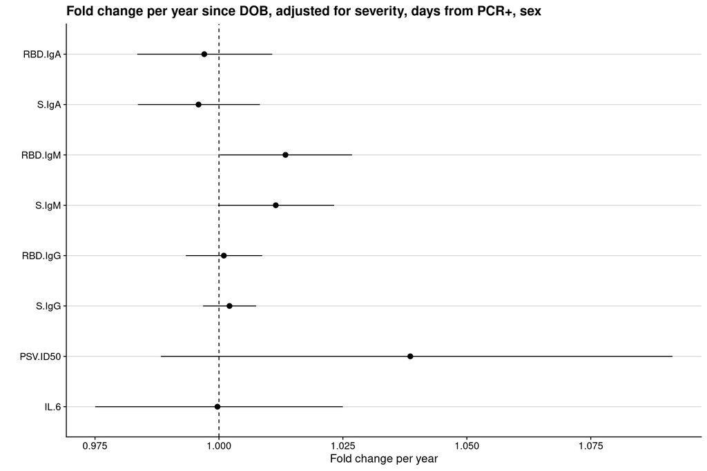

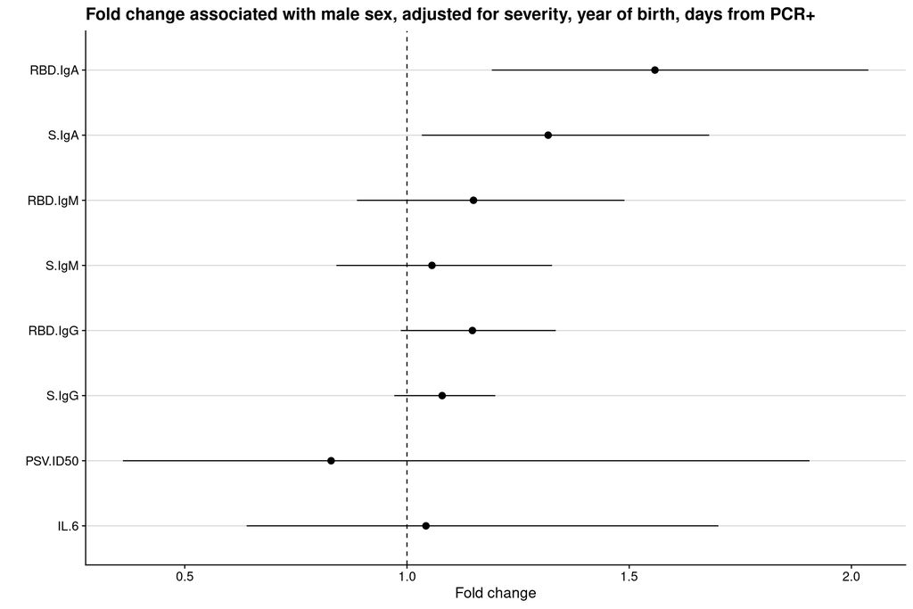

# Notes from Xaq

> In our cross-sectional patient cohort, IgG levels trended upward for the first two months post disease onset, whilst IgM and IgA went in the opposing direction

Agreed, evidenced in the multivariate analysis above

> We found anti-viral antibody levels to increase with disease severity (P = X), supporting the lower titres observed in healthy cohort participants. This was most pronounced for anti-RBD IgA, indicative of advancing mucosal disease (P, Fig X).

> females showed lower anti-viral IgA levels than males in non-hospitalised and hospitalised groups (Supp Fig X),

This is seen in the raw data, and is nominally significant for RBD IgA in the multivariate analysis. However, given the number of tests for a relationship with sex, it wouldn’t survive any form of multiple testing correction, so I wouldn’t make a big deal of it unless there is some prior finding you are trying to replicate.

> In agreement with older individuals being more susceptible to COVID-19, and the effect of ageing on the human immune system (ref, ref, ref), date of birth was negatively correlated with all features in the dataset (Fig X).

> Disease severity and IgA levels also correlated with elevated serum IL-6

Agreed

> As observed for antibody titres, patients showed a large range of neutralisation capacity, with increased anti-viral antibody levels, and intensive care occupancy, correlating with increased neutralisation capacity. Importantly, neutralisation was more strongly associated with anti-RBD, than anti-spike levels for all isotypes (Fig X), with anti-RBD IgG the strongest predictor of neutralisation capacity.

This appears to be true, though you need to be cautious about making claims for RBD vs Spike, unless you are absolutely sure that assays for each have identical levels of noise.

# Notes for methods

All univariate comparisons were performed using non-parametric analyisis (Kruskal-Wallis, stratified Mann-Whitney, hypergeometric exact tests and Spearman rank correlation), while multivariate comparisons were performed using linear regression of log transformed measures and Wald tests. For multivariate tests, all biochemical measures (IL-6, PSV, IgG, IgA, IgM) were log transformed for analysis, to improve symmetry of the distribution.